# Networked Data Lab analysis on unpaid carers

The Health Foundation

2023-07-11

## NDL areas and data availability

[figure not shown]

## Link to central analysis plan

[LINK TO ANALYSIS PLAN ON SHAREPOINT](https://thehealthfoundation98.sharepoint.com/:p:/s/thf_project/projects_programmes/00223/ETuWWtMSOLhAsjhQlKwGsL0Bsw-I7wPZO_gjhNwRJZI3-g?e=eBPdod)

## Table 1: Lookback period

- Labs looked for SNOMED/READ unpaid carer codes and ASC data flags indicating someone is an unpaid carers during this period - [refer to analysis 1 in central analysis plan](https://thehealthfoundation98.sharepoint.com/:p:/s/thf_project/projects_programmes/00223/ETuWWtMSOLhAsjhQlKwGsL0Bsw-I7wPZO_gjhNwRJZI3-g?e=eBPdod).
- Each person has an index date during this period, corresponding to the earliest GP or ASC event.

### Neath Port Talbot (Wales)

| local_authority | source | period_start | period_end |
| --- | --- | --- | --- |
| Neath Port Talbot | GP | 01/07/2017 | 30/06/2022 |
| Neath Port Talbot | LA | 01/07/2017 | 30/06/2022 |

### Swansea (Wales)

| local_authority | source | period_start | period_end |
| --- | --- | --- | --- |
| Swansea | GP | 01/04/2021 | 31/05/2022 |
| Swansea | LA | 01/04/2021 | 31/05/2022 |

### North West London

| local_authority | source | period_start | period_end |
| --- | --- | --- | --- |
| North West London | GP | 01/01/2016 | 31/12/2021 |

### Liverpool and Wirral

| local_authority | source | period_start | period_end |
| --- | --- | --- | --- |
| Liverpool and Wirral | GP | 01/01/2016 | 31/12/2021 |
| Liverpool and Wirral | LA | 01/01/2016 | 31/12/2021 |

### Leeds

| local_authority | source | period_start | period_end |
| --- | --- | --- | --- |
| Leeds | GP | 1/1/2016 | 31/12/2021 |
| Leeds | LA | 1/1/2016 | 31/12/2021 |

## Chart 1: Number of unpaid carers identified per year, by local authority

- **How to read:** In Neath Port Talbot, in 2021, 241 carers were identified in GP data and 53 were identified in local authority data (some may have appeared in both datasets in 2021). This is in comparison to the 16,565 carers identfied in the 2021 Census.

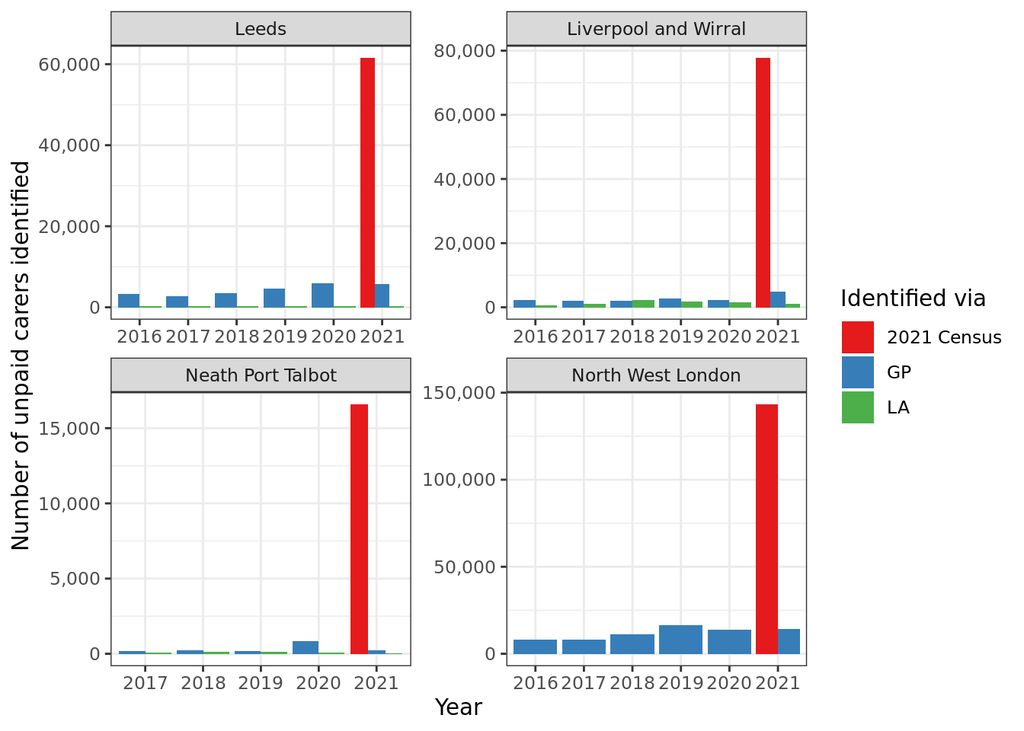

| source | local_authority | count | type_level |
| --- | --- | --- | --- |
| 2021 Census | Leeds | 61490 | 2021 |
| 2021 Census | Liverpool and Wirral | 77680 | 2021 |
| 2021 Census | Neath Port Talbot | 16565 | 2021 |
| 2021 Census | North West London | 143140 | 2021 |
| LA | Neath Port Talbot | 75 | 2017 |
| GP | Neath Port Talbot | 198 | 2017 |
| LA | Neath Port Talbot | 123 | 2018 |
| GP | Neath Port Talbot | 224 | 2018 |
| LA | Neath Port Talbot | 106 | 2019 |
| GP | Neath Port Talbot | 162 | 2019 |
| LA | Neath Port Talbot | 83 | 2020 |
| GP | Neath Port Talbot | 827 | 2020 |
| LA | Neath Port Talbot | 53 | 2021 |
| GP | Neath Port Talbot | 241 | 2021 |
| GP | North West London | 8284 | 2016 |
| GP | North West London | 8216 | 2017 |
| GP | North West London | 10969 | 2018 |
| GP | North West London | 16391 | 2019 |
| GP | North West London | 13763 | 2020 |
| GP | North West London | 14400 | 2021 |
| LA | Liverpool and Wirral | 603 | 2016 |
| GP | Liverpool and Wirral | 2306 | 2016 |
| LA | Liverpool and Wirral | 1109 | 2017 |
| GP | Liverpool and Wirral | 1930 | 2017 |
| LA | Liverpool and Wirral | 2299 | 2018 |
| GP | Liverpool and Wirral | 2052 | 2018 |
| LA | Liverpool and Wirral | 1693 | 2019 |
| GP | Liverpool and Wirral | 2783 | 2019 |
| LA | Liverpool and Wirral | 1434 | 2020 |
| GP | Liverpool and Wirral | 2186 | 2020 |
| LA | Liverpool and Wirral | 1189 | 2021 |
| GP | Liverpool and Wirral | 4952 | 2021 |
| LA | Leeds | 252 | 2016 |
| GP | Leeds | 3204 | 2016 |
| LA | Leeds | 198 | 2017 |
| GP | Leeds | 2743 | 2017 |
| LA | Leeds | 272 | 2018 |
| GP | Leeds | 3403 | 2018 |
| LA | Leeds | 320 | 2019 |
| GP | Leeds | 4654 | 2019 |
| LA | Leeds | 304 | 2020 |
| GP | Leeds | 5879 | 2020 |
| LA | Leeds | 216 | 2021 |
| GP | Leeds | 5825 | 2021 |

## Chart 2: Overlap between GP and ASC data

### Neath Port Talbot (Wales)

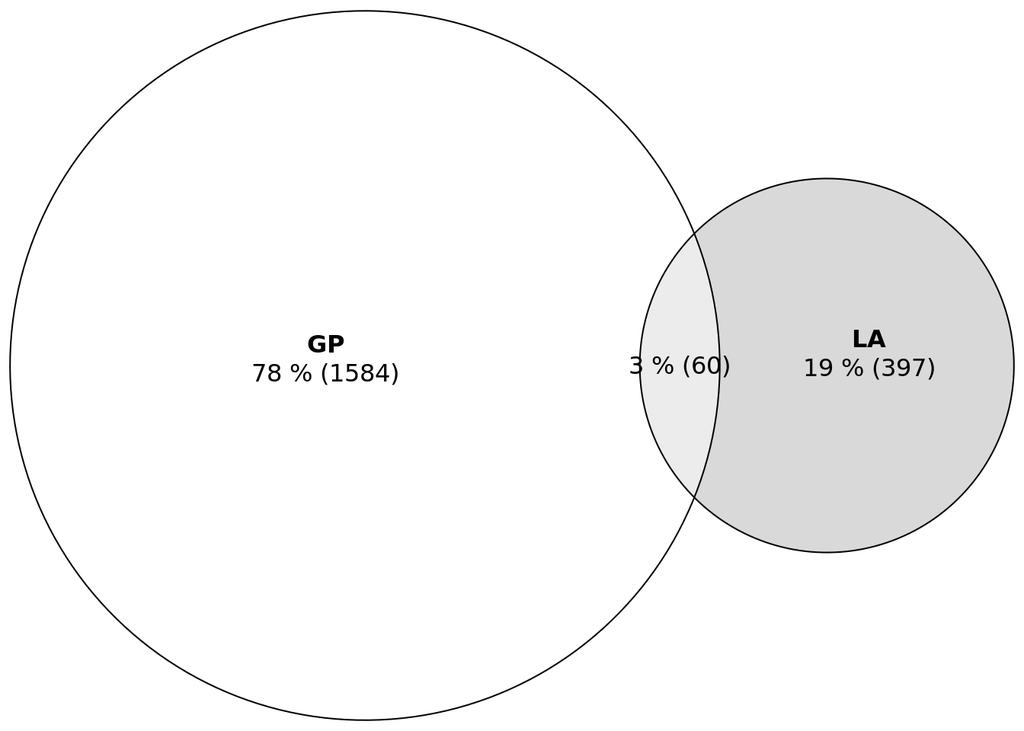

| source | period_start | period_end | local_authority | count | type | type_level |
| --- | --- | --- | --- | --- | --- | --- |
| GP and LA | 01/07/2017 | 30/06/2022 | Neath Port Talbot | 60 | all carers | all carers |
| GP only | 01/07/2017 | 30/06/2022 | Neath Port Talbot | 1584 | all carers | all carers |
| LA only | 01/07/2017 | 30/06/2022 | Neath Port Talbot | 397 | all carers | all carers |

### Swansea (Wales)

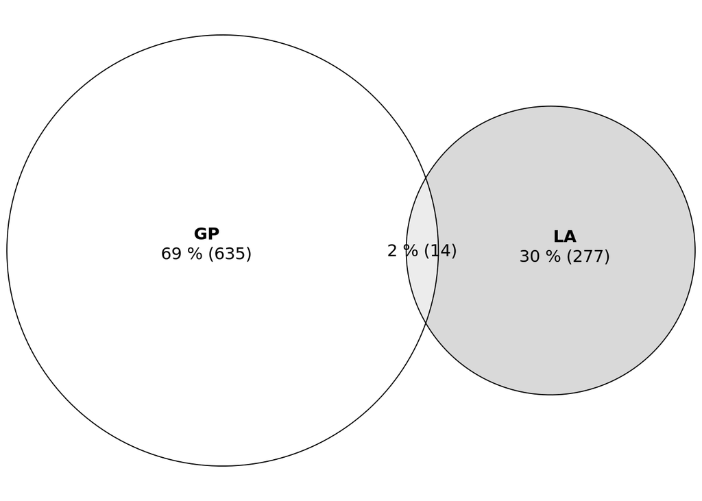

| source | period_start | period_end | local_authority | count | type | type_level |
| --- | --- | --- | --- | --- | --- | --- |
| GP and LA | 01/04/2021 | 31/05/2022 | Swansea | 14 | all carers | all carers |
| GP only | 01/04/2021 | 31/05/2022 | Swansea | 635 | all carers | all carers |
| LA only | 01/04/2021 | 31/05/2022 | Swansea | 277 | all carers | all carers |

### North West London

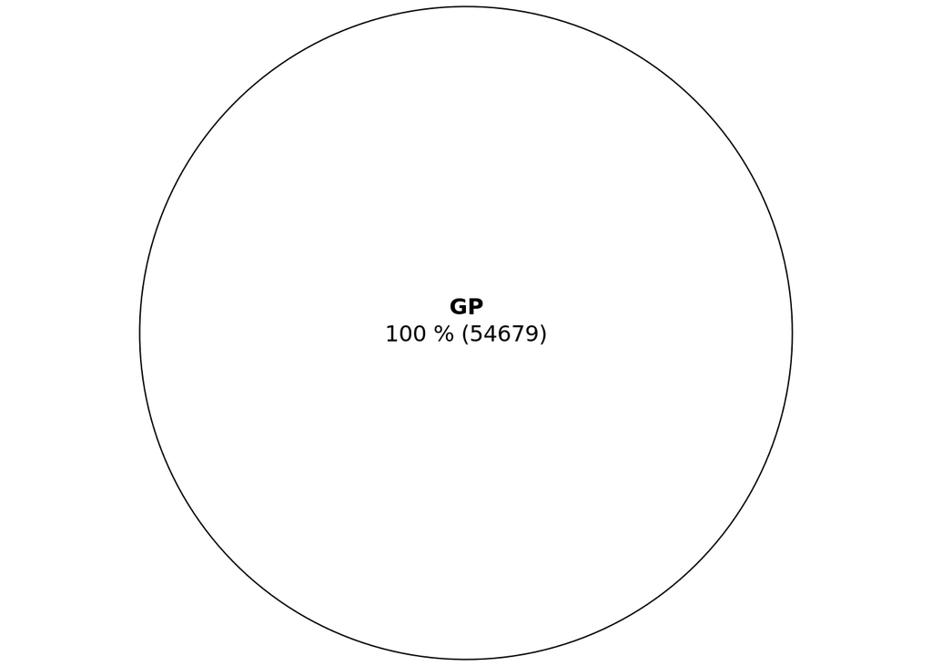

| source | period_start | period_end | local_authority | count | type | type_level |
| --- | --- | --- | --- | --- | --- | --- |
| GP | 01/01/2016 | 31/12/2021 | North West London | 54679 | all carers | all carers |

### Liverpool and Wirral

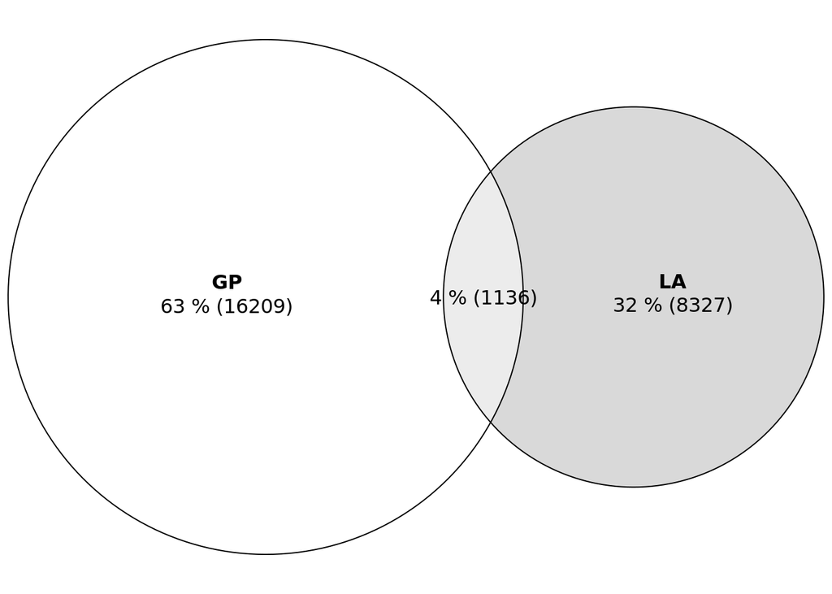

| source | period_start | period_end | local_authority | count | type | type_level |
| --- | --- | --- | --- | --- | --- | --- |
| GP and LA | 01/01/2016 | 31/12/2021 | Liverpool and Wirral | 1136 | all carers | all carers |
| LA only | 01/01/2016 | 31/12/2021 | Liverpool and Wirral | 8327 | all carers | all carers |
| GP only | 01/01/2016 | 31/12/2021 | Liverpool and Wirral | 16209 | all carers | all carers |

### Leeds

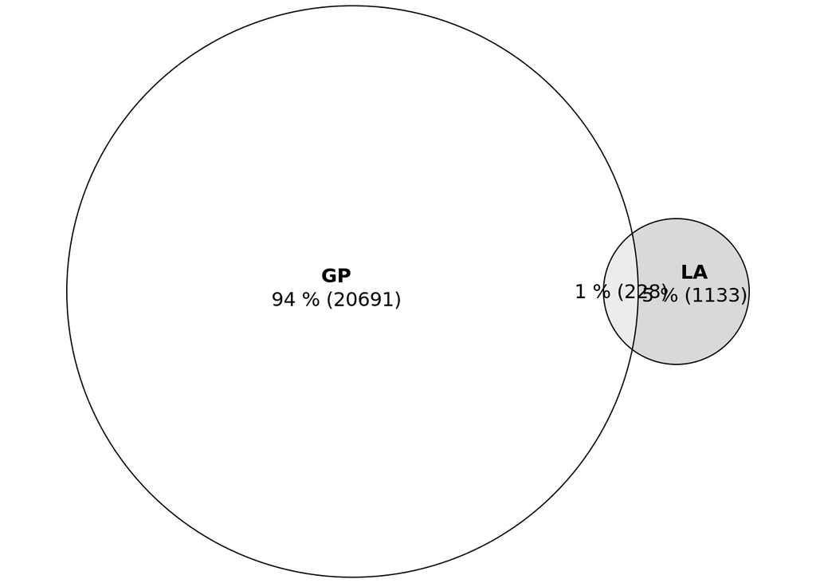

| source | period_start | period_end | local_authority | count | type | type_level |
| --- | --- | --- | --- | --- | --- | --- |
| GP and LA | 1/1/2016 | 31/12/2021 | Leeds | 228 | all carers | all carers |
| GP only | 1/1/2016 | 31/12/2021 | Leeds | 20691 | all carers | all carers |
| LA only | 1/1/2016 | 31/12/2021 | Leeds | 1133 | all carers | all carers |

## Chart 3: Carers in administrative records compared to census [absolute]

- **How to read:** In Neath Port Talbot, over the entire period, 2,024 people were identified as unpaid carers in either GP or ASC records (GP ∪ ASC). According to the 2021 Census, there were 16,565 unpaid carers in Neath Port Talbot in March 2021.

### Neath Port Talbot (Wales)

| source | period_start | period_end | local_authority | count | type | type_level | percent |
| --- | --- | --- | --- | --- | --- | --- | --- |
| 2021 Census | 21/3/2021 | 21/3/2021 | Neath Port Talbot | 16565 | all carers | all carers | 0.8911184 |
| GP or LA | 01/07/2017 | 30/06/2022 | Neath Port Talbot | 2024 | all carers | all carers | 0.1088816 |

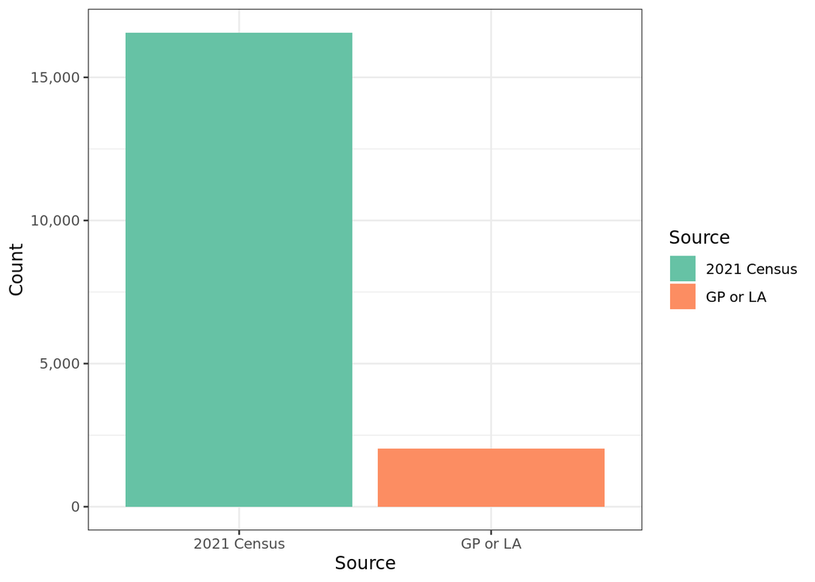

### Swansea (Wales)

| source | period_start | period_end | local_authority | count | type | type_level | percent |
| --- | --- | --- | --- | --- | --- | --- | --- |
| 2021 Census | 21/3/2021 | 21/3/2021 | Swansea | 24720 | all carers | all carers | 0.963893 |
| GP or LA | 01/04/2021 | 31/05/2022 | Swansea | 926 | all carers | all carers | 0.036107 |

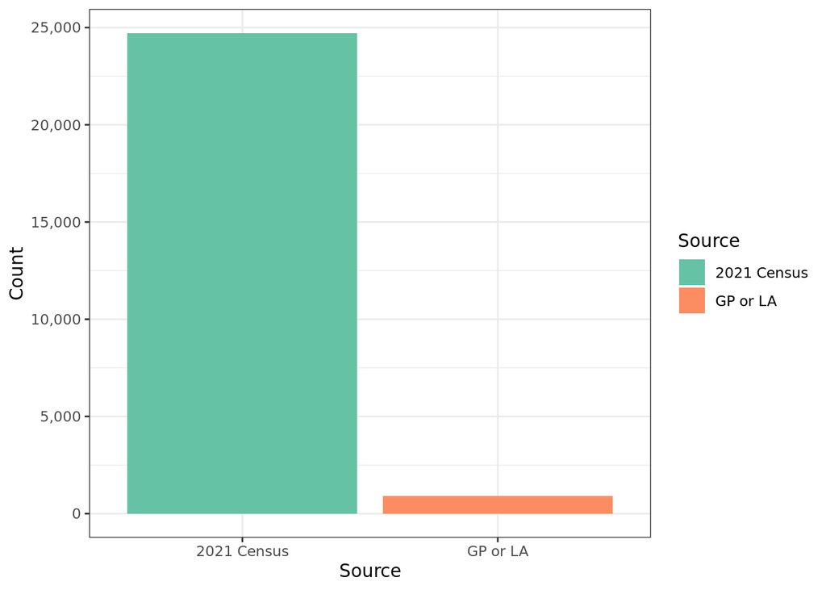

### North West London

| source | period_start | period_end | local_authority | count | type | type_level | percent |
| --- | --- | --- | --- | --- | --- | --- | --- |
| 2021 Census | 21/3/2021 | 21/3/2021 | North West London | 143140 | all carers | all carers | 0.7235908 |
| GP | 01/01/2016 | 31/12/2021 | North West London | 54679 | all carers | all carers | 0.2764092 |

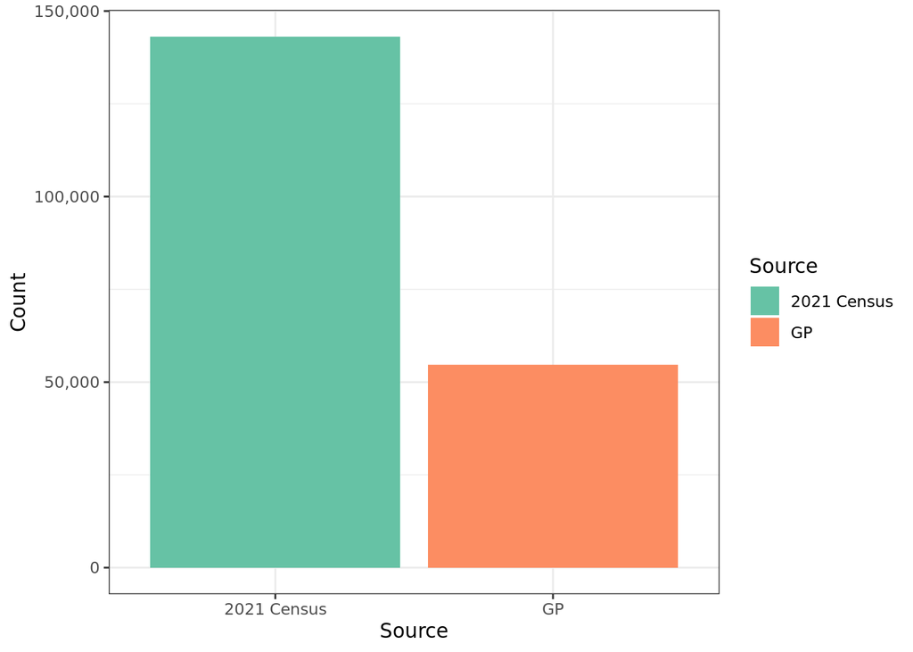

### Liverpool and Wirral

| source | period_start | period_end | local_authority | count | type | type_level | percent |
| --- | --- | --- | --- | --- | --- | --- | --- |
| 2021 Census | 21/3/2021 | 21/3/2021 | Liverpool and Wirral | 77680 | all carers | all carers | 0.7516062 |
| GP or LA | 01/01/2016 | 31/12/2021 | Liverpool and Wirral | 25672 | all carers | all carers | 0.2483938 |

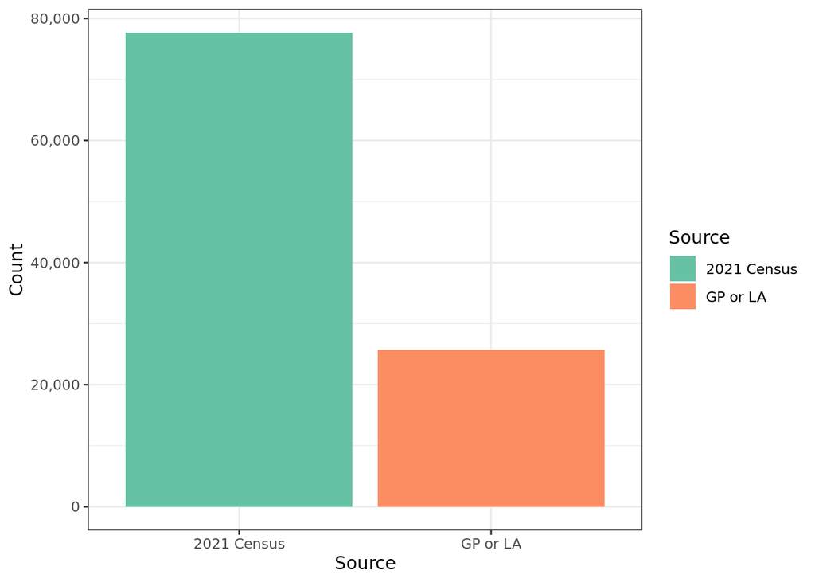

### Leeds

| source | period_start | period_end | local_authority | count | type | type_level | percent |
| --- | --- | --- | --- | --- | --- | --- | --- |
| 2021 Census | 21/3/2021 | 21/3/2021 | Leeds | 61490 | all carers | all carers | 0.736037 |
| GP or LA | 1/1/2016 | 31/12/2021 | Leeds | 22052 | all carers | all carers | 0.263963 |

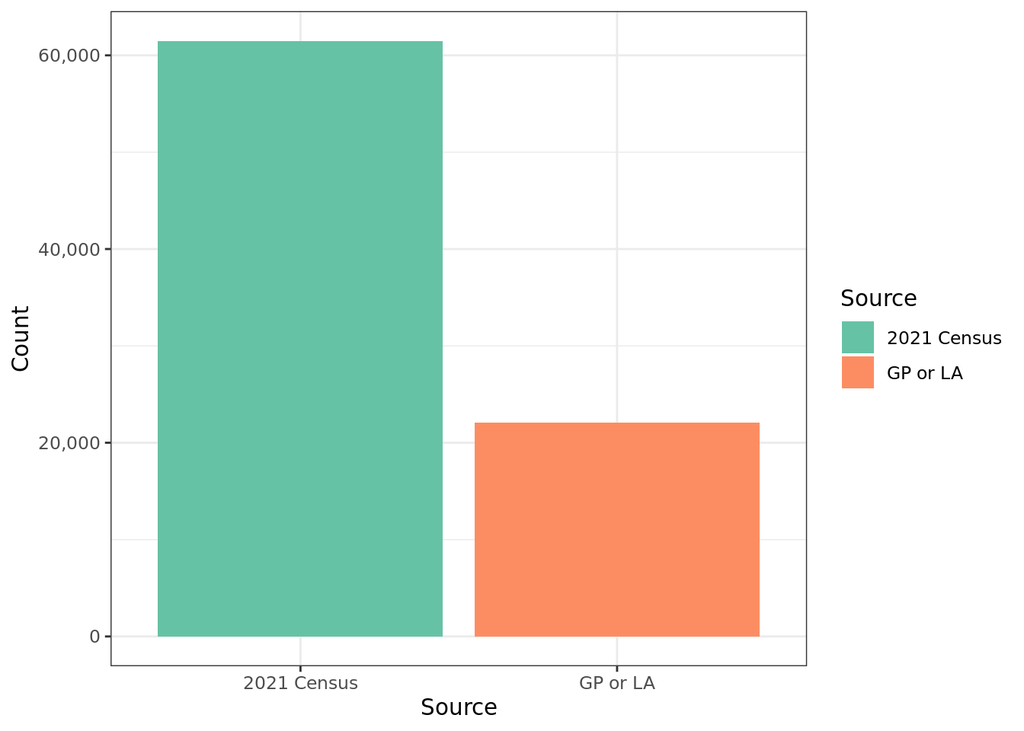

## Chart 4: Carers in administrative records compared to census [relative]

- **How to read:** In Neath Port Talbot, over the entire period, 2,024 people were identified as unpaid carers in either GP or ASC records (GP ∪ ASC). According to the 2021 Census, there were 16,565 unpaid carers in Neath Port Talbot in March 2021. Therefore, 11% of unpaid carers in Neath Port Talbot were successfully identified in administrative records - *assuming they are the one and same population*.

### Neath Port Talbot (Wales)

| source | period_start | period_end | local_authority | count | type | type_level | percent |
| --- | --- | --- | --- | --- | --- | --- | --- |
| 2021 Census | 21/3/2021 | 21/3/2021 | Neath Port Talbot | 16565 | all carers | all carers | 0.8911184 |
| GP or LA | 01/07/2017 | 30/06/2022 | Neath Port Talbot | 2024 | all carers | all carers | 0.1088816 |

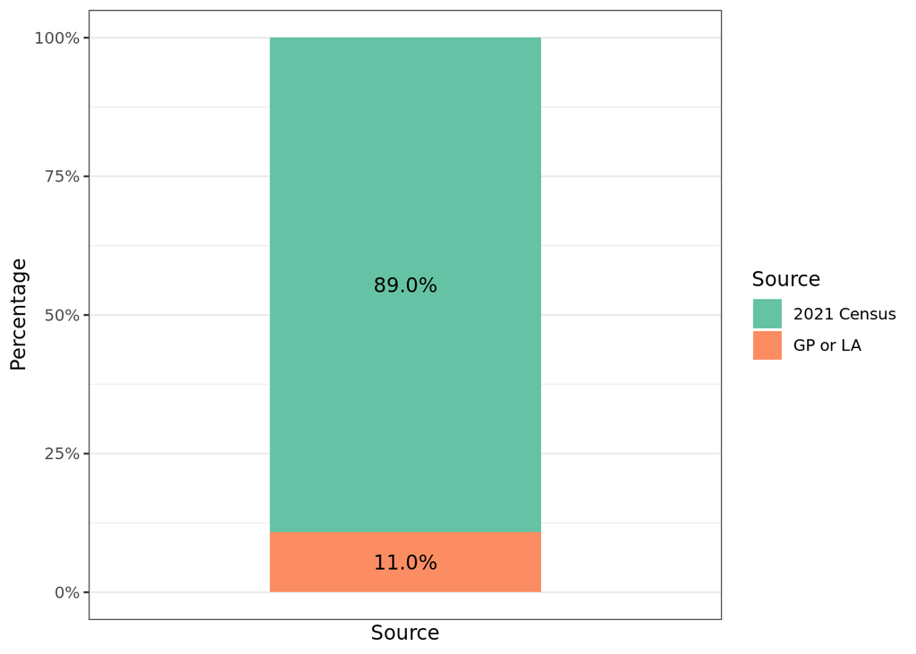

### Swansea (Wales)

| source | period_start | period_end | local_authority | count | type | type_level | percent |
| --- | --- | --- | --- | --- | --- | --- | --- |
| 2021 Census | 21/3/2021 | 21/3/2021 | Swansea | 24720 | all carers | all carers | 0.963893 |
| GP or LA | 01/04/2021 | 31/05/2022 | Swansea | 926 | all carers | all carers | 0.036107 |

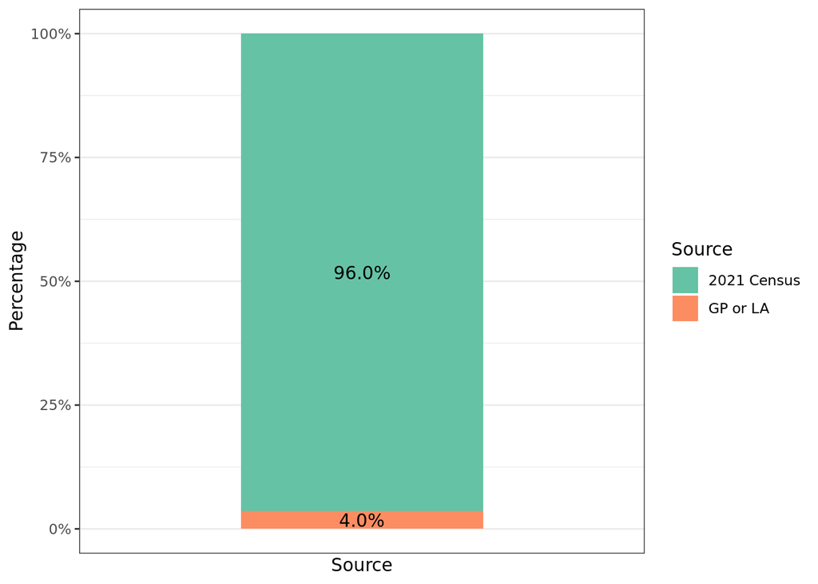

### North West London

| source | period_start | period_end | local_authority | count | type | type_level | percent |
| --- | --- | --- | --- | --- | --- | --- | --- |
| 2021 Census | 21/3/2021 | 21/3/2021 | North West London | 143140 | all carers | all carers | 0.7235908 |
| GP | 01/01/2016 | 31/12/2021 | North West London | 54679 | all carers | all carers | 0.2764092 |

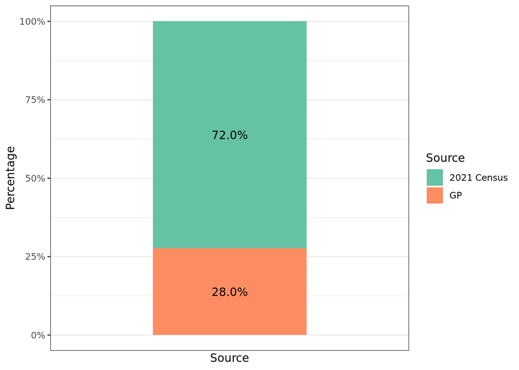

### Liverpool and Wirral

| source | period_start | period_end | local_authority | count | type | type_level | percent |
| --- | --- | --- | --- | --- | --- | --- | --- |
| 2021 Census | 21/3/2021 | 21/3/2021 | Liverpool and Wirral | 77680 | all carers | all carers | 0.7516062 |
| GP or LA | 01/01/2016 | 31/12/2021 | Liverpool and Wirral | 25672 | all carers | all carers | 0.2483938 |

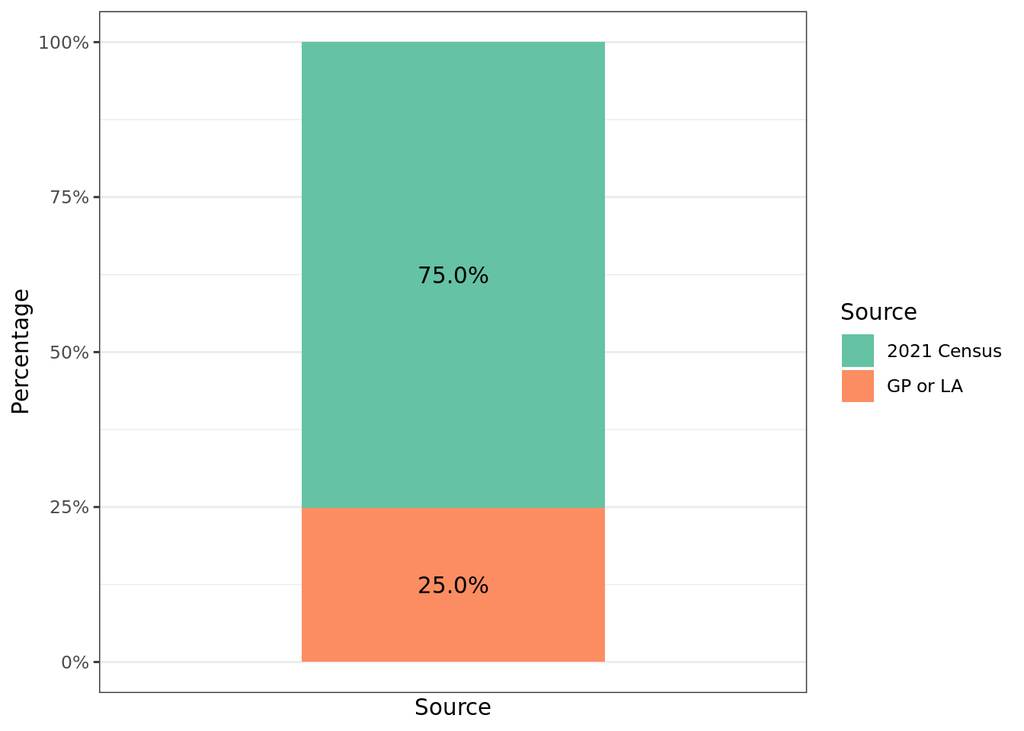

### Leeds

| source | period_start | period_end | local_authority | count | type | type_level | percent |
| --- | --- | --- | --- | --- | --- | --- | --- |
| 2021 Census | 21/3/2021 | 21/3/2021 | Leeds | 61490 | all carers | all carers | 0.736037 |
| GP or LA | 1/1/2016 | 31/12/2021 | Leeds | 22052 | all carers | all carers | 0.263963 |

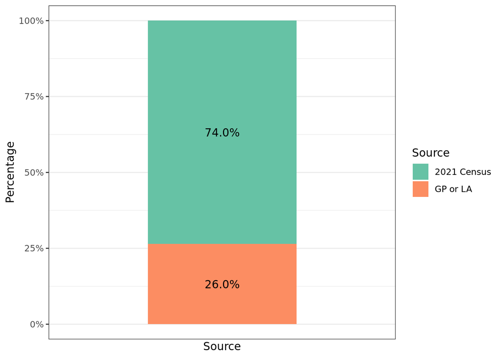

## Chart 5: Sex distribution of carer cohorts

- **How to read:** In Neath Port Talbot, over the entire period, 68% of unpaid carers identified in GP records were female compared to 70% of unpaid carers identified in ASC records.

### Neath Port Talbot (Wales)

| source | period_start | period_end | local_authority | count | type | type_level | source_total | pct_source |
| --- | --- | --- | --- | --- | --- | --- | --- | --- |
| GP | 01/07/2017 | 30/06/2022 | Neath Port Talbot | 1093 | sex | female | 1611 | 67.84606 |
| GP | 01/07/2017 | 30/06/2022 | Neath Port Talbot | 518 | sex | male | 1611 | 32.15394 |
| LA | 01/07/2017 | 30/06/2022 | Neath Port Talbot | 289 | sex | female | 413 | 69.97579 |
| LA | 01/07/2017 | 30/06/2022 | Neath Port Talbot | 124 | sex | male | 413 | 30.02421 |

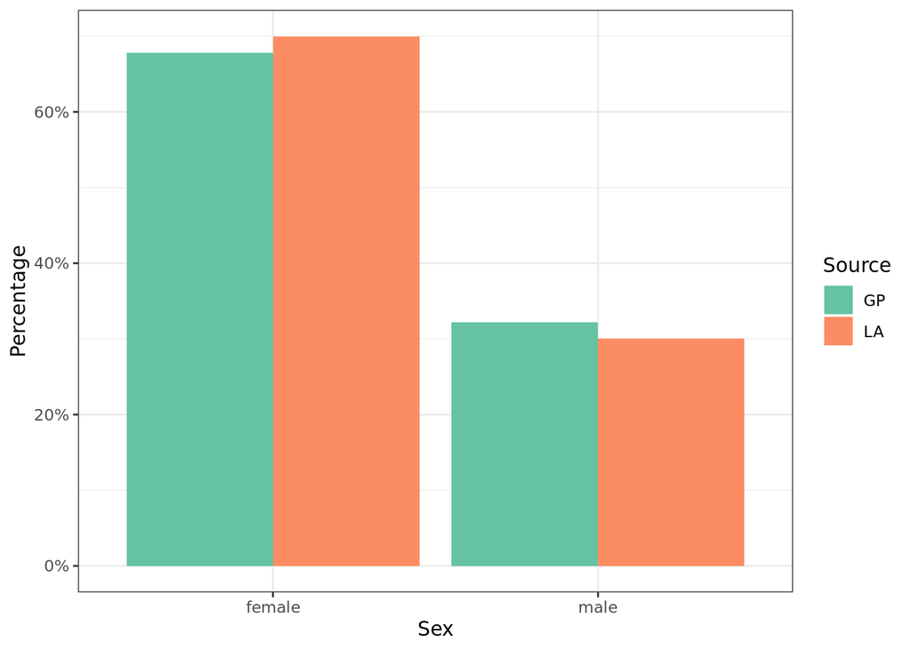

### Swansea (Wales)

| source | period_start | period_end | local_authority | count | type | type_level | source_total | pct_source |
| --- | --- | --- | --- | --- | --- | --- | --- | --- |
| GP | 01/04/2021 | 31/05/2022 | Swansea | 411 | sex | female | 645 | 63.72093 |
| GP | 01/04/2021 | 31/05/2022 | Swansea | 234 | sex | male | 645 | 36.27907 |
| LA | 01/04/2021 | 31/05/2022 | Swansea | 196 | sex | female | 281 | 69.75089 |
| LA | 01/04/2021 | 31/05/2022 | Swansea | 85 | sex | male | 281 | 30.24911 |

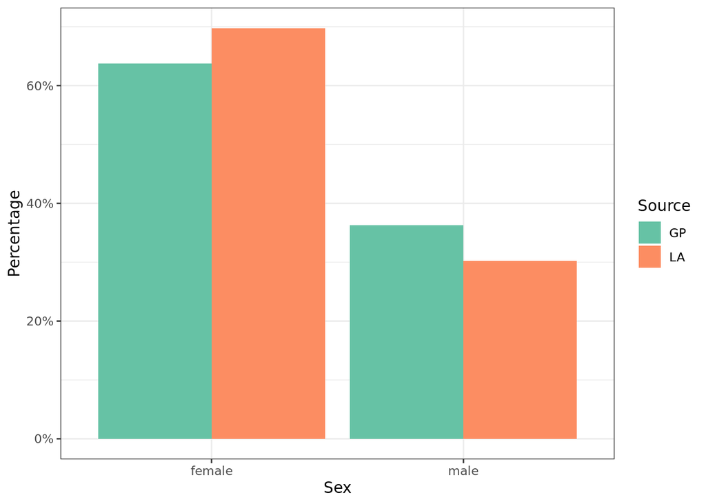

### North West London

| source | period_start | period_end | local_authority | count | type | type_level | source_total | pct_source |
| --- | --- | --- | --- | --- | --- | --- | --- | --- |
| GP | 01/01/2016 | 31/12/2021 | North West London | 35089 | sex | female | 54678 | 64.17389 |
| GP | 01/01/2016 | 31/12/2021 | North West London | 19589 | sex | male | 54678 | 35.82611 |

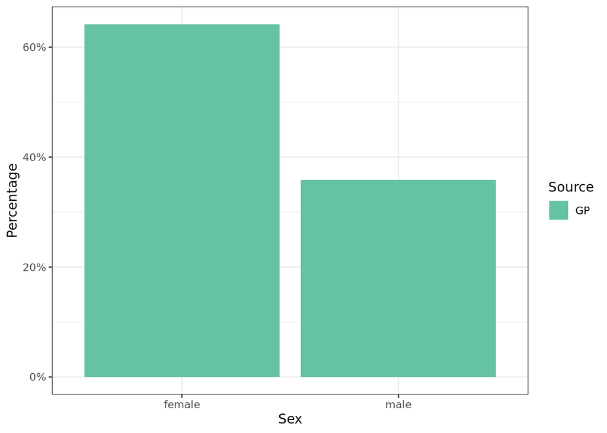

### Liverpool and Wirral

| source | period_start | period_end | local_authority | count | type | type_level | source_total | pct_source |
| --- | --- | --- | --- | --- | --- | --- | --- | --- |
| GP | 01/01/2016 | 31/12/2021 | Liverpool and Wirral | 6372 | sex | female | 9470 | 67.28617 |
| GP | 01/01/2016 | 31/12/2021 | Liverpool and Wirral | 3098 | sex | male | 9470 | 32.71383 |
| LA | 01/01/2016 | 31/12/2021 | Liverpool and Wirral | 1950 | sex | female | 3028 | 64.39894 |
| LA | 01/01/2016 | 31/12/2021 | Liverpool and Wirral | 1078 | sex | male | 3028 | 35.60106 |

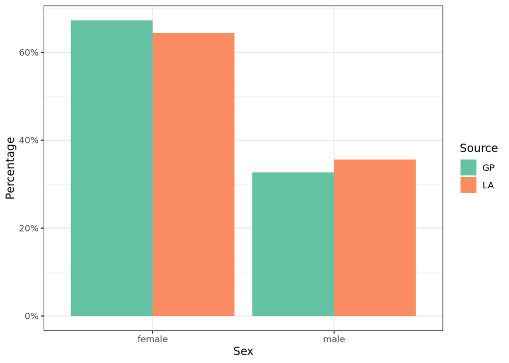

### Leeds

| source | period_start | period_end | local_authority | count | type | type_level | source_total | pct_source |
| --- | --- | --- | --- | --- | --- | --- | --- | --- |
| GP | 1/1/2016 | 31/12/2021 | Leeds | 11796 | sex | female | 18372 | 64.20640 |
| GP | 1/1/2016 | 31/12/2021 | Leeds | 6576 | sex | male | 18372 | 35.79360 |
| LA | 1/1/2016 | 31/12/2021 | Leeds | 916 | sex | female | 1334 | 68.66567 |
| LA | 1/1/2016 | 31/12/2021 | Leeds | 418 | sex | male | 1334 | 31.33433 |

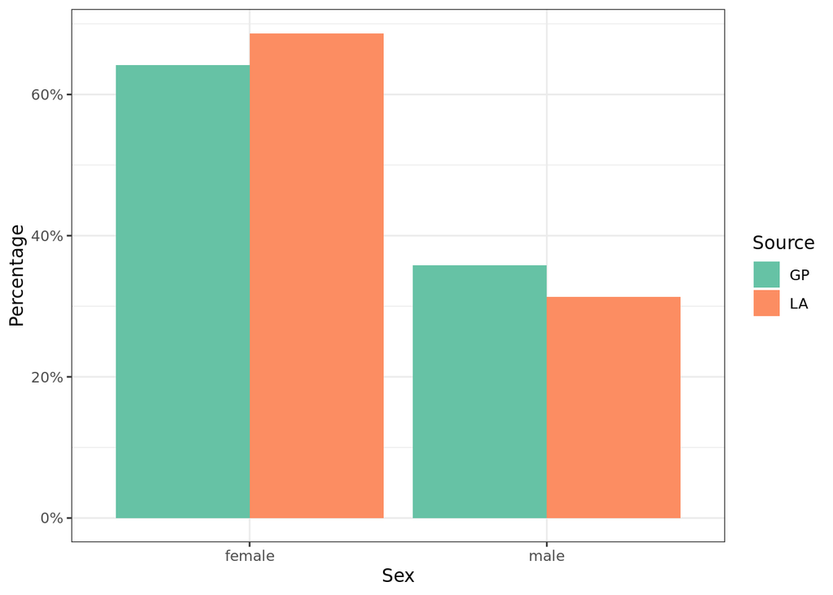

## Chart 6: Age distribution of carer cohorts

- **How to read:** In Neath Port Talbot, over the entire period, 21% of unpaid carers identified in GP records were under the age of 40 compared to 6% of unpaid carers identified in ASC records.

### Neath Port Talbot (Wales)

| source | period_start | period_end | local_authority | count | type | type_level | source_total | pct_source |
| --- | --- | --- | --- | --- | --- | --- | --- | --- |
| GP | 01/07/2017 | 30/06/2022 | Neath Port Talbot | 333 | age | under 40 | 1611 | 20.670391 |
| GP | 01/07/2017 | 30/06/2022 | Neath Port Talbot | 301 | age | 40-49 | 1611 | 18.684047 |
| GP | 01/07/2017 | 30/06/2022 | Neath Port Talbot | 473 | age | 50-59 | 1611 | 29.360646 |
| GP | 01/07/2017 | 30/06/2022 | Neath Port Talbot | 314 | age | 60-69 | 1611 | 19.490999 |
| GP | 01/07/2017 | 30/06/2022 | Neath Port Talbot | 93 | age | 70-79 | 1611 | 5.772812 |
| GP | 01/07/2017 | 30/06/2022 | Neath Port Talbot | 97 | age | 80+ | 1611 | 6.021105 |
| LA | 01/07/2017 | 30/06/2022 | Neath Port Talbot | 25 | age | under 40 | 413 | 6.053269 |
| LA | 01/07/2017 | 30/06/2022 | Neath Port Talbot | 40 | age | 40-49 | 413 | 9.685230 |
| LA | 01/07/2017 | 30/06/2022 | Neath Port Talbot | 98 | age | 50-59 | 413 | 23.728814 |
| LA | 01/07/2017 | 30/06/2022 | Neath Port Talbot | 104 | age | 60-69 | 413 | 25.181598 |
| LA | 01/07/2017 | 30/06/2022 | Neath Port Talbot | 79 | age | 70-79 | 413 | 19.128329 |
| LA | 01/07/2017 | 30/06/2022 | Neath Port Talbot | 67 | age | 80+ | 413 | 16.222760 |

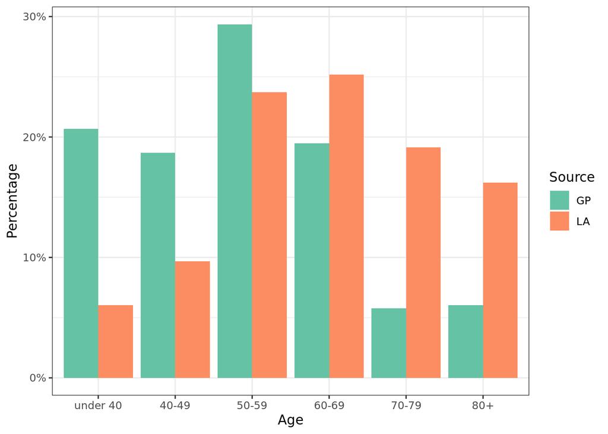

### Swansea (Wales)

| source | period_start | period_end | local_authority | count | type | type_level | source_total | pct_source |
| --- | --- | --- | --- | --- | --- | --- | --- | --- |
| GP | 01/04/2021 | 31/05/2022 | Swansea | 84 | age | under 40 | 645 | 13.023256 |
| GP | 01/04/2021 | 31/05/2022 | Swansea | 83 | age | 40-49 | 645 | 12.868217 |
| GP | 01/04/2021 | 31/05/2022 | Swansea | 129 | age | 50-59 | 645 | 20.000000 |
| GP | 01/04/2021 | 31/05/2022 | Swansea | 107 | age | 60-69 | 645 | 16.589147 |
| GP | 01/04/2021 | 31/05/2022 | Swansea | 94 | age | 70-79 | 645 | 14.573643 |
| GP | 01/04/2021 | 31/05/2022 | Swansea | 148 | age | 80+ | 645 | 22.945736 |
| LA | 01/04/2021 | 31/05/2022 | Swansea | 14 | age | under 40 | 281 | 4.982206 |
| LA | 01/04/2021 | 31/05/2022 | Swansea | 22 | age | 40-49 | 281 | 7.829181 |
| LA | 01/04/2021 | 31/05/2022 | Swansea | 48 | age | 50-59 | 281 | 17.081851 |
| LA | 01/04/2021 | 31/05/2022 | Swansea | 53 | age | 60-69 | 281 | 18.861210 |
| LA | 01/04/2021 | 31/05/2022 | Swansea | 77 | age | 70-79 | 281 | 27.402135 |
| LA | 01/04/2021 | 31/05/2022 | Swansea | 67 | age | 80+ | 281 | 23.843416 |

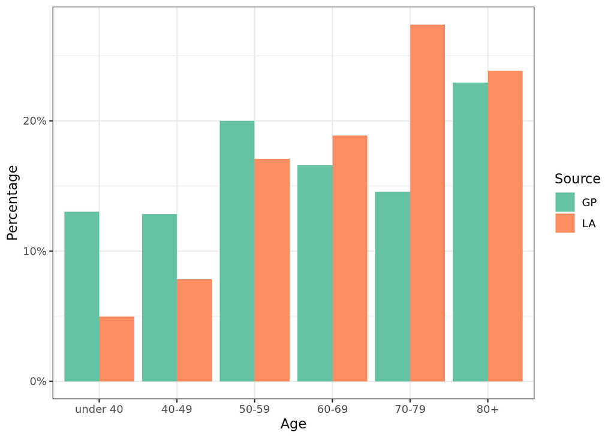

### North West London

| source | period_start | period_end | local_authority | count | type | type_level | source_total | pct_source |
| --- | --- | --- | --- | --- | --- | --- | --- | --- |
| GP | 01/01/2016 | 31/12/2021 | North West London | 2982 | age | 18-29 | 54679 | 5.453648 |
| GP | 01/01/2016 | 31/12/2021 | North West London | 6521 | age | 30-39 | 54679 | 11.925968 |
| GP | 01/01/2016 | 31/12/2021 | North West London | 7914 | age | 40-49 | 54679 | 14.473564 |
| GP | 01/01/2016 | 31/12/2021 | North West London | 8813 | age | 50-59 | 54679 | 16.117705 |
| GP | 01/01/2016 | 31/12/2021 | North West London | 8601 | age | 60-69 | 54679 | 15.729988 |
| GP | 01/01/2016 | 31/12/2021 | North West London | 7784 | age | 70-79 | 54679 | 14.235813 |
| GP | 01/01/2016 | 31/12/2021 | North West London | 12064 | age | 80+ | 54679 | 22.063315 |

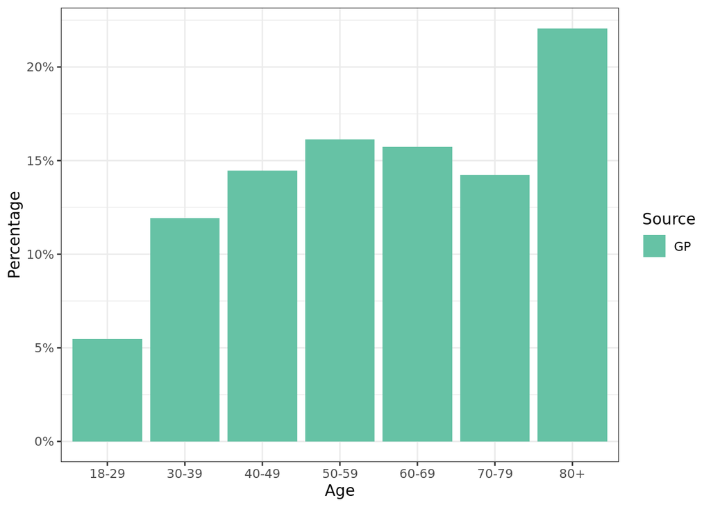

### Liverpool and Wirral

| source | period_start | period_end | local_authority | count | type | type_level | source_total | pct_source |
| --- | --- | --- | --- | --- | --- | --- | --- | --- |
| GP | 01/01/2016 | 31/12/2021 | Liverpool and Wirral | 1053 | age | 18-29 | 9470 | 11.119324 |
| GP | 01/01/2016 | 31/12/2021 | Liverpool and Wirral | 1426 | age | 30-39 | 9470 | 15.058078 |
| GP | 01/01/2016 | 31/12/2021 | Liverpool and Wirral | 1714 | age | 40-49 | 9470 | 18.099261 |
| GP | 01/01/2016 | 31/12/2021 | Liverpool and Wirral | 2379 | age | 50-59 | 9470 | 25.121436 |
| GP | 01/01/2016 | 31/12/2021 | Liverpool and Wirral | 1688 | age | 60-69 | 9470 | 17.824710 |
| GP | 01/01/2016 | 31/12/2021 | Liverpool and Wirral | 717 | age | 70-79 | 9470 | 7.571278 |
| GP | 01/01/2016 | 31/12/2021 | Liverpool and Wirral | 493 | age | 80+ | 9470 | 5.205913 |
| LA | 01/01/2016 | 31/12/2021 | Liverpool and Wirral | 85 | age | 18-29 | 3028 | 2.807133 |
| LA | 01/01/2016 | 31/12/2021 | Liverpool and Wirral | 74 | age | 30-39 | 3028 | 2.443857 |
| LA | 01/01/2016 | 31/12/2021 | Liverpool and Wirral | 197 | age | 40-49 | 3028 | 6.505945 |
| LA | 01/01/2016 | 31/12/2021 | Liverpool and Wirral | 387 | age | 50-59 | 3028 | 12.780713 |
| LA | 01/01/2016 | 31/12/2021 | Liverpool and Wirral | 476 | age | 60-69 | 3028 | 15.719947 |
| LA | 01/01/2016 | 31/12/2021 | Liverpool and Wirral | 639 | age | 70-79 | 3028 | 21.103038 |
| LA | 01/01/2016 | 31/12/2021 | Liverpool and Wirral | 1170 | age | 80+ | 3028 | 38.639366 |

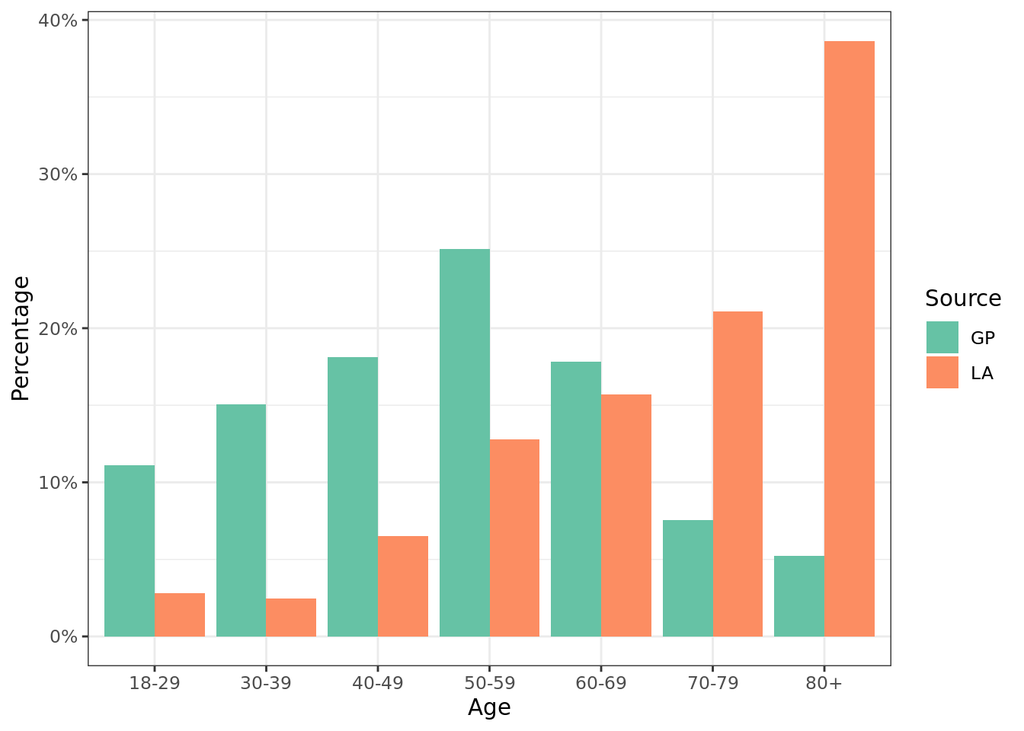

### Leeds

| source | period_start | period_end | local_authority | count | type | type_level | source_total | pct_source |
| --- | --- | --- | --- | --- | --- | --- | --- | --- |
| GP | 1/1/2016 | 31/12/2021 | Leeds | 1318 | age | 18-29 | 20919 | 6.300492 |
| GP | 1/1/2016 | 31/12/2021 | Leeds | 1968 | age | 30-39 | 20919 | 9.407716 |
| GP | 1/1/2016 | 31/12/2021 | Leeds | 2927 | age | 40-49 | 20919 | 13.992065 |
| GP | 1/1/2016 | 31/12/2021 | Leeds | 3899 | age | 50-59 | 20919 | 18.638558 |
| GP | 1/1/2016 | 31/12/2021 | Leeds | 3318 | age | 60-69 | 20919 | 15.861179 |
| GP | 1/1/2016 | 31/12/2021 | Leeds | 2893 | age | 70-79 | 20919 | 13.829533 |
| GP | 1/1/2016 | 31/12/2021 | Leeds | 2049 | age | 80+ | 20919 | 9.794923 |
| GP | 1/1/2016 | 31/12/2021 | Leeds | 2547 | age | unknown | 20919 | 12.175534 |
| LA | 1/1/2016 | 31/12/2021 | Leeds | 22 | age | 18-29 | 1361 | 1.616459 |
| LA | 1/1/2016 | 31/12/2021 | Leeds | 68 | age | 30-39 | 1361 | 4.996326 |
| LA | 1/1/2016 | 31/12/2021 | Leeds | 142 | age | 40-49 | 1361 | 10.433505 |
| LA | 1/1/2016 | 31/12/2021 | Leeds | 248 | age | 50-59 | 1361 | 18.221896 |
| LA | 1/1/2016 | 31/12/2021 | Leeds | 196 | age | 60-69 | 1361 | 14.401176 |
| LA | 1/1/2016 | 31/12/2021 | Leeds | 227 | age | 70-79 | 1361 | 16.678913 |
| LA | 1/1/2016 | 31/12/2021 | Leeds | 168 | age | 80+ | 1361 | 12.343865 |
| LA | 1/1/2016 | 31/12/2021 | Leeds | 290 | age | unknown | 1361 | 21.307862 |

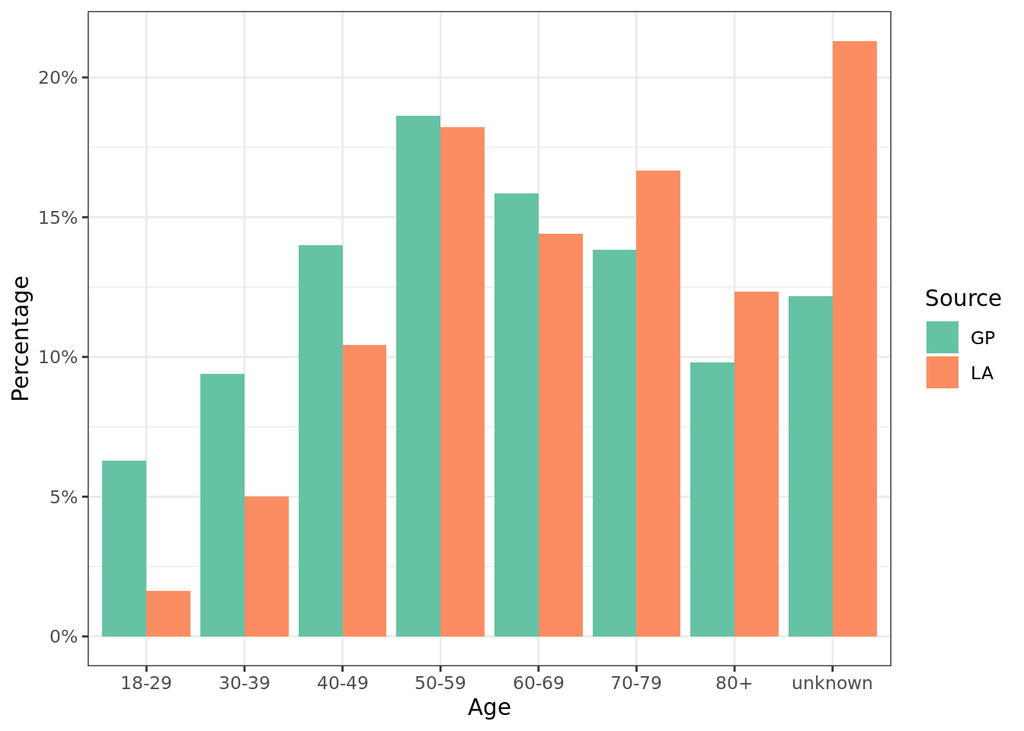